# STAT-184 Final Project

Muhammad Bilal Yaseen

Due Date: 12/16/19 @ 11:59 PM

### Front Matter

#### CRITERIA 1: Data Access

```r
Airplane_crashes <- read_csv("~/Desktop/Airplane_crashes.csv") #uploading primary dataset
```

```
3 parsing failures.
 row  col   expected   actual                             file
 159 Time valid date 91:05:00 '~/Desktop/Airplane_crashes.csv'
2126 Time valid date 90:00:00 '~/Desktop/Airplane_crashes.csv'
3101 Time valid date 24:05:00 '~/Desktop/Airplane_crashes.csv'
```

```r
head(Airplane_crashes) #inspection works fine
```

| Date | Time | Location | Operator | Flight # | Route | ACType | Registration | cn/ln | Aboard | Aboard Passangers | Aboard Crew | Fatalities | Fatalities Passangers | Fatalities_Crew | Ground | Summary |
| --- | --- | --- | --- | --- | --- | --- | --- | --- | --- | --- | --- | --- | --- | --- | --- | --- |
| 9/17/08 | 17:18:00 | Fort Myer, Virginia | Military - U.S. Army | NA | Demonstration | Wright Flyer III | NA | 1 | 2 | 1 | 1 | 1 | 1 | 0 | 0 | During a demonstration flight, a U.S. Army flyer flown by Orville Wright nose-dived into the ground from a height of approximately 75 feet, killing Lt. Thomas E. Selfridge, 26, who was a passenger. Th… |
| 9/7/09 | NA | Juvisy-sur-Orge, France | NA | NA | Air show | Wright Byplane | SC1 | NA | 1 | 0 | 1 | 1 | 0 | 0 | 0 | Eugene Lefebvre was the first pilot to ever be killed in an air accident, after his controls jambed while flying in an air show. |
| 7/12/12 | 06:30:00 | Atlantic City, New Jersey | Military - U.S. Navy | NA | Test flight | Dirigible | NA | NA | 5 | 0 | 5 | 5 | 0 | 5 | 0 | First U.S. dirigible Akron exploded just offshore at an altitude of 1,000 ft. during a test flight. |
| 8/6/13 | NA | Victoria, British Columbia, Canada | Private | NA | NA | Curtiss seaplane | NA | NA | 1 | 0 | 1 | 1 | 0 | 1 | 0 | The first fatal airplane accident in Canada occurred when American barnstormer, John M. Bryant, California aviator was killed. |
| 9/9/13 | 18:30:00 | Over the North Sea | Military - German Navy | NA | NA | Zeppelin L-1 (airship) | NA | NA | 20 | NULL | NULL | 14 | NULL | NULL | 0 | The airship flew into a thunderstorm and encountered a severe downdraft crashing 20 miles north of Helgoland Island into the sea. The ship broke in two and the control car immediately sank drowning it… |
| 10/17/13 | 10:30:00 | Near Johannisthal, Germany | Military - German Navy | NA | NA | Zeppelin L-2 (airship) | NA | NA | 30 | NULL | NULL | 30 | NULL | NULL | 0 | Hydrogen gas which was being vented was sucked into the forward engine and ignited causing the airship to explode and burn at 3,000 ft.. |

```r
str(Airplane_crashes) #inspection works fine
```

```
Classes ‘spec_tbl_df’, ‘tbl_df’, ‘tbl’ and 'data.frame':    4967 obs. of  17 variables:
 $ Date                 : chr  "9/17/08" "9/7/09" "7/12/12" "8/6/13" ...
 $ Time                 : 'hms' num  17:18:00 NA 06:30:00 NA ...
  ..- attr(*, "units")= chr "secs"
 $ Location             : chr  "Fort Myer, Virginia" "Juvisy-sur-Orge, France" "Atlantic City, New Jersey" "Victoria, British Columbia, Canada" ...
 $ Operator             : chr  "Military - U.S. Army" NA "Military - U.S. Navy" "Private" ...
 $ Flight #             : chr  NA NA NA NA ...
 $ Route                : chr  "Demonstration" "Air show" "Test flight" NA ...
 $ ACType               : chr  "Wright Flyer III" "Wright Byplane" "Dirigible" "Curtiss seaplane" ...
 $ Registration         : chr  NA "SC1" NA NA ...
 $ cn/ln                : chr  "1" NA NA NA ...
 $ Aboard               : chr  "2" "1" "5" "1" ...
 $ Aboard Passangers    : chr  "1" "0" "0" "0" ...
 $ Aboard Crew          : chr  "1" "1" "5" "1" ...
 $ Fatalities           : chr  "1" "1" "5" "1" ...
 $ Fatalities Passangers: chr  "1" "0" "0" "0" ...
 $ Fatalities_Crew      : chr  "0" "0" "5" "1" ...
 $ Ground               : chr  "0" "0" "0" "0" ...
 $ Summary              : chr  "During a demonstration flight, a U.S. Army flyer flown by Orville Wright nose-dived into the ground from a heig"| __truncated__ "Eugene Lefebvre was the first pilot to ever be killed in an air accident, after his controls jambed while flyin"| __truncated__ "First U.S.…
 - attr(*, "problems")=Classes ‘tbl_df’, ‘tbl’ and 'data.frame':    3 obs. of  5 variables:
  ..$ row     : int  159 2126 3101
  ..$ col     : chr  "Time" "Time" "Time"
  ..$ expected: chr  "valid date" "valid date" "valid date"
  ..$ actual  : chr  "91:05:00" "90:00:00" "24:05:00"
  ..$ file    : chr  "'~/Desktop/Airplane_crashes.csv'" "'~/Desktop/Airplane_crashes.csv'" "'~/Desktop/Airplane_crashes.csv'"
 - attr(*, "spec")=
  .. cols(
  ..   Date = col_character(),
  ..   Time = col_time(format = ""),
  ..   Location = col_character(),
  ..   Operator = col_character(),
  ..   `Flight #` = col_character(),
  ..   Route = col_character(),
  ..   ACType = col_character(),
  ..   Registration = col_character(),
  ..   `cn/ln` = col_character(),
  ..   Aboard = col_character(),
  ..   `Aboard Passangers` = col_character(),
  ..   `Aboard Crew` = col_character(),
  ..   Fatalities = col_character(),
  ..   `Fatalities Passangers` = col_character(),
  ..   Fatalities_Crew = col_character(),
  ..   Ground = col_character(),
  ..   Summary = col_character()
  .. )
```

```r
Airplane_crash_fleet <- read_csv("~/Desktop/Fleet_data.csv") #uploading secondary dataset
head(Airplane_crash_fleet) #inspection works fine
```

| Parent Airline | Operator | ACType | Current | Future | Historic | Total | Orders | UnitCost_mn | TotalCost_mn | Average_age(yrs) |
| --- | --- | --- | --- | --- | --- | --- | --- | --- | --- | --- |
| Aegean Airlines | Aegean Airlines | Airbus A319 | 1 | NA | 3 | 4 | NA | $90 | $90 | 11.6 |
| Aegean Airlines | Olympic Air | Airbus A319 | NA | NA | 8 | 8 | NA | $90 | $0 | NA |
| Aegean Airlines | Aegean Airlines | Airbus A320 | 38 | NA | 3 | 41 | NA | $98 | $3,724 | 7.5 |
| Aegean Airlines | Olympic Air | Airbus A320 | NA | NA | 9 | 9 | NA | $98 | $0 | NA |
| Aegean Airlines | Aegean Airlines | Airbus A321 | 8 | NA | NA | 8 | NA | $115 | $919 | 10.3 |
| Aegean Airlines | Olympic Air | ATR 42/72 | 2 | NA | NA | 2 | NA | $22 | $44 | 2.4 |

```r
str(Airplane_crash_fleet) #inspection works fine
```

```
Classes ‘spec_tbl_df’, ‘tbl_df’, ‘tbl’ and 'data.frame':    1583 obs. of  11 variables:
 $ Parent Airline  : chr  "Aegean Airlines" "Aegean Airlines" "Aegean Airlines" "Aegean Airlines" ...
 $ Operator        : chr  "Aegean Airlines" "Olympic Air" "Aegean Airlines" "Olympic Air" ...
 $ ACType          : chr  "Airbus A319" "Airbus A319" "Airbus A320" "Airbus A320" ...
 $ Current         : num  1 NA 38 NA 8 2 NA NA NA 12 ...
 $ Future          : num  NA NA NA NA NA NA NA NA NA NA ...
 $ Historic        : num  3 8 3 9 NA NA 6 17 6 7 ...
 $ Total           : num  4 8 41 9 8 2 6 17 6 19 ...
 $ Orders          : num  NA NA NA NA NA NA NA NA NA NA ...
 $ UnitCost_mn     : chr  "$90" "$90" "$98" "$98" ...
 $ TotalCost_mn    : chr  "$90" "$0" "$3,724" "$0" ...
 $ Average_age(yrs): num  11.6 NA 7.5 NA 10.3 2.4 NA NA NA 12.6 ...
 - attr(*, "spec")=
  .. cols(
  ..   `Parent Airline` = col_character(),
  ..   Operator = col_character(),
  ..   ACType = col_character(),
  ..   Current = col_double(),
  ..   Future = col_double(),
  ..   Historic = col_double(),
  ..   Total = col_double(),
  ..   Orders = col_double(),
  ..   UnitCost_mn = col_character(),
  ..   TotalCost_mn = col_character(),
  ..   `Average_age(yrs)` = col_double()
  .. )
```

#### CRITERIA 2: Data Wrangling

*Description of code chunk below:* Since primary dataset contains alot of non-civilian crashes as well (like military), I extracted civilian ones and named the data frame Civilian_plane_crashes. It is grouped in a specific way as the code shows. Datasets are huge, so I used view() to comprehensively inspect data modifications at every stage.

```r
Civilian_plane_crashes <-
  Airplane_crashes %>%                               #inputting primary dataset for read
  filter(Operator != "Military") %>%                 #filtering out military crashes
  group_by(Operator, ACType, Fatalities, Date) %>%   #ACType means Air Craft Type
  summarise() %>%
  view()
```

*Description of code chunk below:* Fatalities is in chr data type so I converted the data type by using as.numeric. After that it was possible for me to run aggregation and find out the total fatalities per Operator for the civilian plane crashes. These fatalities are for the entire century so thats why numbers are huge. Note that despite of filtering out military plane crashes, some still appear in my dataset. But its not a problem because I filtered them out manually as I proceeded. This code helped me figure out the answer to my question: which airline was the most safe and unsafe. It can be seen most safe one was Trans Canada Air Lines with just 212 fatalities over the whole century and the least safe one was Aeroflot with 8858 fatalities over the whole century.

```r
Civilian_plane_crashes$Fatalities <- as.numeric(Civilian_plane_crashes$Fatalities) #conversion to appropriate data type
```

```
NAs introduced by coercion
```

```r
Civilian_plane_crashes %>%
  group_by(Operator) %>%                            #grouping by Operator (i.e. Airline)
  summarise(totalfatalities = sum(Fatalities)) %>%  #summing total fatalities
  filter(rank(desc(totalfatalities)) <= 100) %>%    #top 100 Operators ranked according to Fatalities
  arrange(desc(totalfatalities))                    #arranging from highest to least
```

| Operator | totalfatalities |
| --- | --- |
| Aeroflot | 8858 |
| Military - U.S. Air Force | 3356 |
| Air France | 1757 |
| American Airlines | 1422 |
| Pan American World Airways | 1303 |
| Military - U.S. Army Air Forces | 1048 |
| United Air Lines | 1019 |
| AVIANCA | 941 |
| Turkish Airlines (THY) | 890 |
| Indian Airlines | 860 |

[output cut: 90 more lines]

*Description of code chunk below:* Here I am working with the secondary dataset. For the columns ‘UnitCost_mn’ and ‘TotalCost_mn’, there is dollar sign along with numbers like $90. Data must be in same format so I used regex (gsub) to clean the columns from dollar sign. Also the reason I needed to do this was because I have to sum TotalCost_mn later on and it wont happen unless dollar sign is taken care of.

```r
Airplane_crash_fleet %>%                                                           #cleaning data using regex expressions
  mutate(UnitCost_mn = gsub(pattern = "[$]", replacement = "", UnitCost_mn),       #removing $ sign from UnitCost_mn and TotalCost_mn
         TotalCost_mn = gsub(pattern = "[$]", replacement = "", TotalCost_mn))     # mn is million so $90mn is $90 million
```

| Parent Airline | Operator | ACType | Current | Future | Historic | Total | Orders | UnitCost_mn | TotalCost_mn | Average_age(yrs) |
| --- | --- | --- | --- | --- | --- | --- | --- | --- | --- | --- |
| Aegean Airlines | Aegean Airlines | Airbus A319 | 1 | NA | 3 | 4 | NA | 90 | 90 | 11.6 |
| Aegean Airlines | Olympic Air | Airbus A319 | NA | NA | 8 | 8 | NA | 90 | 0 | NA |
| Aegean Airlines | Aegean Airlines | Airbus A320 | 38 | NA | 3 | 41 | NA | 98 | 3,724 | 7.5 |
| Aegean Airlines | Olympic Air | Airbus A320 | NA | NA | 9 | 9 | NA | 98 | 0 | NA |
| Aegean Airlines | Aegean Airlines | Airbus A321 | 8 | NA | NA | 8 | NA | 115 | 919 | 10.3 |
| Aegean Airlines | Olympic Air | ATR 42/72 | 2 | NA | NA | 2 | NA | 22 | 44 | 2.4 |
| Aegean Airlines | Aegean Airlines | ATR 42/72 | NA | NA | 6 | 6 | NA | 22 | 0 | NA |
| Aegean Airlines | Aegean Airlines | Boeing 737 | NA | NA | 17 | 17 | NA | 74 | 0 | NA |
| Aegean Airlines | Aegean Airlines | British Aerospace BAe 146/Avro RJ | NA | NA | 6 | 6 | NA | 14 | 0 | NA |
| Aegean Airlines | Olympic Air | De Havilland Canada DHC-8 Dash 8 | 12 | NA | 7 | 19 | NA | 31 | 376 | 12.6 |

[output cut: 990 more lines]

*Description of code chunk below:* Here I created data frame Plane_info which is to be used for a join later. This data frame shows the planes that were involved in the crash grouped with their specific operators and costs.

```r
Plane_info <-
  Airplane_crash_fleet %>%
  mutate(UnitCost_mn = gsub(pattern = "[$]", replacement = "", UnitCost_mn)) %>%
  group_by(Operator, ACType, UnitCost_mn) %>%
  summarise() %>%
  view()
```

*Description of code chunk below:* Here I created a data frame called Cabai (in short for Crash Analysis By Airplane Information). It gets formed by a join between two data frames (Civilian_plane_crashes & Plane_info). I did this join so that its easy to see which operator carried how many fatalities and what tyoe of plane was involved. This code helped me figure out the answer to my question: which plane was the most safe and unsafe. It can be seen that safest is Boeing because despite of multiple crashes, it had 0 fatalities for Operators like British Airways, Southwest Airlines etc. The least safe were Douglas, Tupolev, Antonov because their fatalities surpassed Boeing’s by alot. This makes sense because Tupolev and Antonov are both Russian manufactured planes operated by Aeroflot which is Russian airline. So if Aeroflot was the least safe airline, it explains planes like Tupolev and Antonov were the reason behind it because they had so many fatalities. Note that fatalities data type was changed so that its possible to arrange it in descending order.

```r
Civilian_plane_crashes$Fatalities <- as.numeric(Civilian_plane_crashes$Fatalities)

Cabai <-    #Crash analysis by airplane information (in short Cabai)
  merge.data.frame(Civilian_plane_crashes, Plane_info, by = c('Operator')) %>%   #joining data frame by key = Operator
  group_by(Operator, Fatalities, ACType.x, Date) %>%                             #grouping in a specific way
  summarise() %>%
  arrange(desc(Fatalities)) %>%                                                  #fatalities in descending order
  view()
```

*Description of code chunk below:* Here I created a data frame called Operators_totalloss which shows the total loss incurred by different operators in the entire century due to plane crashes. UniCost_mn was changed to appropriate data type so that it could be aggregated. This code helped me figure out answer to my question: which airline operator had the most financial loss and the least financial loss over the century. It can be seen that Air France suffered the most loss with USD 3071 million and Aviance Honduras suffered the least loss with just USD 22 million. Note here I am able to aggregate UnitCost_mn because I changed its data type and also in the previous codes I used regex to ger rid of the dollar sign.

```r
Plane_info$UnitCost_mn <- as.numeric(Plane_info$UnitCost_mn)

Operators_totalloss <-                                          #Operator or Airline total loss (regrading airplanes) for 19th century
  Plane_info %>%
  group_by(Operator) %>%
  summarise(totalloss_USDmillions = sum(UnitCost_mn)) %>%
  arrange(desc(totalloss_USDmillions)) %>%
  view()
```

#### CRITERIA 3: Data Visualization

##### NOTE:

While doing visualizations, for most of the parts I had to restrict the amount of data that gets plotted. This is because my datasets are so huge that its not possible for me to plot the datatsets in entirety. I did try plotting entire datasets but R studio would either crash in between, take too long to load or give me a graph thats too messy to make sense of. So I worked with visualizations that made the mose sense.

*Description of code chunk below:* Here I am making a comparison of top seven airlines that faced the most financial losses throughout the century. Air France exceeds every other airline. Data frame Operators_totalloss was used here.

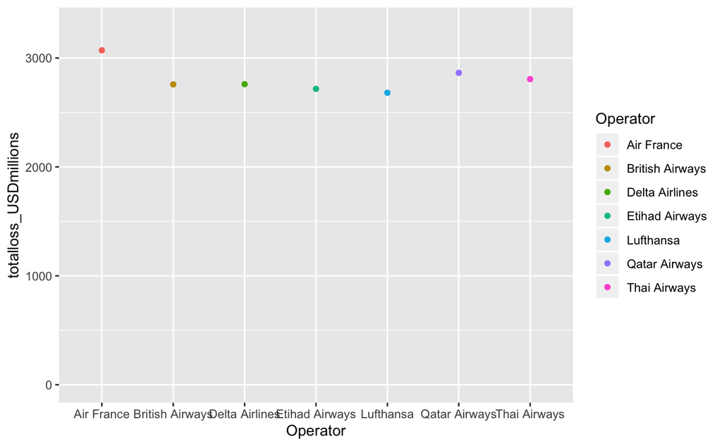

```r
G1 <-
  head(Operators_totalloss, n=7)

G1 %>%
  ggplot(aes(x = Operator, y = totalloss_USDmillions,
             key = Operator, color = Operator)) +
  geom_point() +
  ylim(0,3300)
```

*Description of code chunk below:* Here I am making a comparison between airlines that counted in top eight for highest number of fatalities. Note that G2 data frame contains two military crashes (row 2 and row 6) which I didn’t wanted to include in my analysis. So the best way I could ignore them was manually selecting which operators I wanted to show along with their corresponding fatalities. All this is shown in code for G3. Aeroflot exceeds every other airline with the number of fatalities.

```r
Civilian_plane_crashes$Fatalities <- as.numeric(Civilian_plane_crashes$Fatalities) #conversion to appropriate data type

G2 <-
Civilian_plane_crashes %>%
  group_by(Operator) %>%
  summarise(totalfatalities = sum(Fatalities)) %>%
  filter(rank(desc(totalfatalities)) <= 100) %>%
  arrange(desc(totalfatalities))

G3 <-
  head(G2, n=10)
G3
```

| Operator | totalfatalities |
| --- | --- |
| Aeroflot | 8858 |
| Military - U.S. Air Force | 3356 |
| Air France | 1757 |
| American Airlines | 1422 |
| Pan American World Airways | 1303 |
| Military - U.S. Army Air Forces | 1048 |
| United Air Lines | 1019 |
| AVIANCA | 941 |
| Turkish Airlines (THY) | 890 |
| Indian Airlines | 860 |

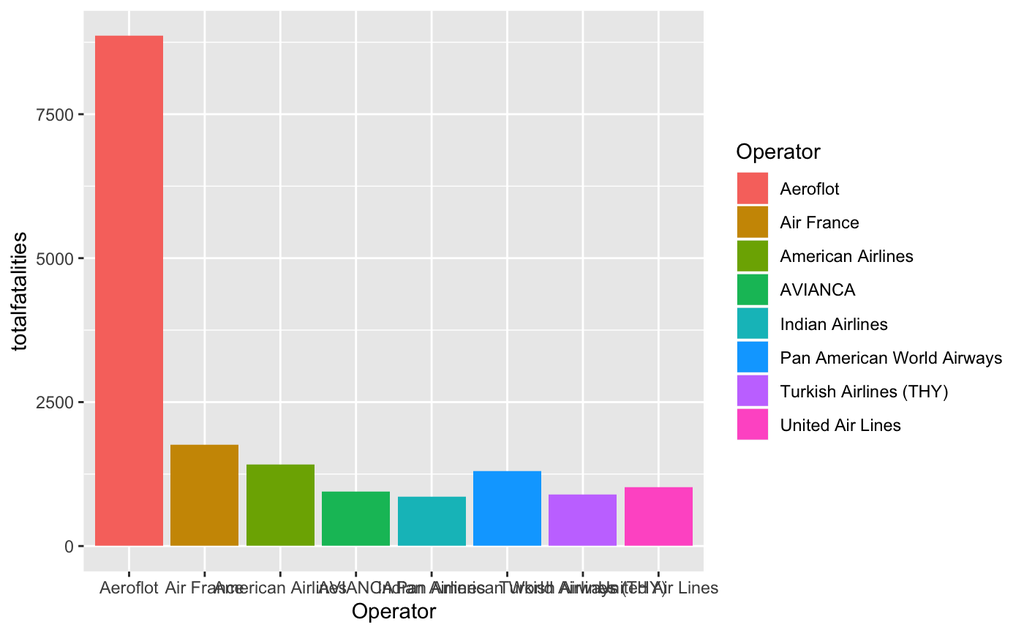

```r
G3 <- data.frame(Operator = c("Aeroflot", "Air France", "American Airlines",
                              "Pan American World Airways", "United Air Lines",
                              "AVIANCA", "Turkish Airlines (THY)",
                              "Indian Airlines"),
                 totalfatalities = c(8858, 1757, 1422, 1303, 1019, 941, 890, 860))
ggplot(G3, aes(x=Operator, y = totalfatalities, key = totalfatalities, fill = Operator)) + geom_bar(stat = "identity")
```

```r
G4 <-
  Civilian_plane_crashes %>%
  mutate(as.Date(Date, "%m/%d/%Y")) %>%  #helps read date as date so to plot it on graph
  arrange(desc(Date))                    #arranging date in ascending order
G4
```

| Operator | ACType | Fatalities | Date | as.Date(Date, "%m/%d/%Y") |
| --- | --- | --- | --- | --- |
| Rusts Flying Service Inc. | de Havilland Dash-2 float plane | 5 | 9/9/98 | 0098-09-09 |
| SAETA | CASA 212 Aviocar 200 | 21 | 9/9/95 | 0095-09-09 |
| Hang Khong (Vietnam) | Tupolev TU-134A | 76 | 9/9/88 | 0088-09-09 |
| Military - U.S. Air Force | Lockheed C-130A Hercules | 3 | 9/9/86 | 0086-09-09 |
| Lineas Areas del Centro | de Havilland Canada DHC-6 Twin Otter 100 | 18 | 9/9/78 | 0078-09-09 |
| Temesco Helicopter - Air Taxi | Soloy 12EJ3 | 3 | 9/9/78 | 0078-09-09 |
| Aeroflot / Aeroflot | Antonov AN-24 / Yakovlev Yak-40 | 64 | 9/9/76 | 0076-09-09 |
| Allegheny Airlines / Forth Corporation | MD Douglas DC-9-31/Piper Cherokee PA-28 | 83 | 9/9/69 | 0069-09-09 |
| Flying Tiger Line | Lockheed L-1049H Super Constellation | 8 | 9/9/58 | 0058-09-09 |
| Continental Airlines | Douglas DC-3 / Cessna 170B | 0 | 9/9/56 | 0056-09-09 |

[output cut: 990 more lines]

```r
G5 <-
  head(G4, n=14)
G3
```

| Operator | totalfatalities |
| --- | --- |
| Aeroflot | 8858 |
| Air France | 1757 |
| American Airlines | 1422 |
| Pan American World Airways | 1303 |
| United Air Lines | 1019 |
| AVIANCA | 941 |
| Turkish Airlines (THY) | 890 |
| Indian Airlines | 860 |

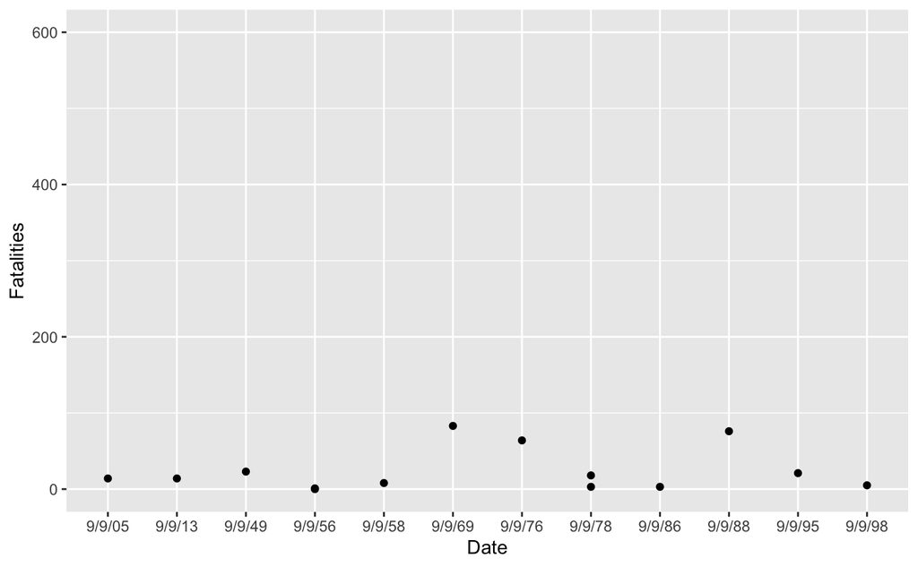

```r
G5 %>%
  ggplot(aes(x = Date, y = Fatalities, key = Fatalities)) +
  ylim(0,600) +
  geom_point()
```

```r
G4 <-
  Civilian_plane_crashes %>%
  mutate(as.Date(Date, "%m/%d/%Y")) %>%   #helps read date as date so to plot it on graph
  arrange(desc(Date))                     #arranging date in descending order
G4
```

| Operator | ACType | Fatalities | Date | as.Date(Date, "%m/%d/%Y") |
| --- | --- | --- | --- | --- |
| Rusts Flying Service Inc. | de Havilland Dash-2 float plane | 5 | 9/9/98 | 0098-09-09 |
| SAETA | CASA 212 Aviocar 200 | 21 | 9/9/95 | 0095-09-09 |
| Hang Khong (Vietnam) | Tupolev TU-134A | 76 | 9/9/88 | 0088-09-09 |
| Military - U.S. Air Force | Lockheed C-130A Hercules | 3 | 9/9/86 | 0086-09-09 |
| Lineas Areas del Centro | de Havilland Canada DHC-6 Twin Otter 100 | 18 | 9/9/78 | 0078-09-09 |
| Temesco Helicopter - Air Taxi | Soloy 12EJ3 | 3 | 9/9/78 | 0078-09-09 |
| Aeroflot / Aeroflot | Antonov AN-24 / Yakovlev Yak-40 | 64 | 9/9/76 | 0076-09-09 |
| Allegheny Airlines / Forth Corporation | MD Douglas DC-9-31/Piper Cherokee PA-28 | 83 | 9/9/69 | 0069-09-09 |
| Flying Tiger Line | Lockheed L-1049H Super Constellation | 8 | 9/9/58 | 0058-09-09 |
| Continental Airlines | Douglas DC-3 / Cessna 170B | 0 | 9/9/56 | 0056-09-09 |

[output cut: 990 more lines]

[figure not shown]

```r
G4 %>%
  ggplot(aes(x = Date, y = Fatalities, key = Fatalities)) +
  geom_point(alpha = 0.02, position = "Jitter") +
  xlab("Plane Crash Dates for the whole 19th century") +
  ylab("Fatalities") +
  geom_col()
```

```r
NA
```

```r
Civilian_plane_crashes <-
  Airplane_crashes %>%
  filter(Operator != "Military") %>%
  group_by(Operator, ACType, Fatalities, Date, Location) %>%
  summarise()

Civilian_plane_crashes$Fatalities <- as.numeric(Civilian_plane_crashes$Fatalities)
```

```
NAs introduced by coercion
```

```
Mapping API still under development and may change in future releases.
4612 items were not translated
```

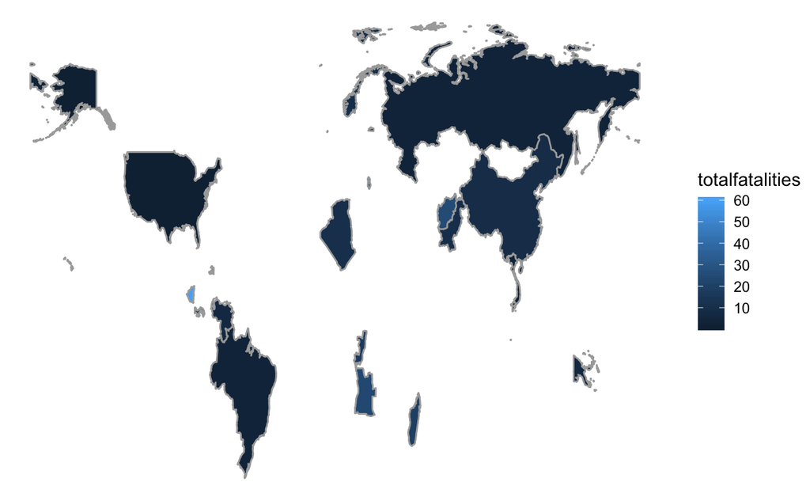

```r
Civilian_plane_crashes1 <-
  Civilian_plane_crashes %>%
  group_by(Operator, Location) %>%
  summarise(totalfatalities = sum(Fatalities)) %>%
  filter(rank(desc(totalfatalities)) <= 100) %>%
  arrange(desc(totalfatalities))

G6 <-
  Civilian_plane_crashes1 %>%
  select(Location, totalfatalities)
WorldMap(G6, key = Location, fill = totalfatalities)
```

The project ends here.